# Initilization

```python
from qiskit import QuantumCircuit, transpile, Aer, execute
from qiskit.visualization import plot_histogram, plot_bloch_multivector
import math
```

For convenience, we first directly fetch our previous written helping functions.

```python
def get_result_from_backend(qc, shots=1000, simulator_name='qasm_simulator'):

    # Choose the backend (simulator or real quantum device)
    backend = Aer.get_backend(simulator_name)

    # Transpile the quantum circuit for the chosen backend
    transpiled_qc = transpile(qc, backend)

    # Execute the quantum circuit on the chosen backend
    result = execute(transpiled_qc, backend, shots=shots).result()

    return result
```

```python
def get_unitary_matrix(qc):
    result = get_result_from_backend(qc,simulator_name='unitary_simulator')
    return result.get_unitary(qc, decimals=3)
```

```python
def get_state_vector(qc):
    result = get_result_from_backend(qc,simulator_name='statevector_simulator')
    statevector = result.get_statevector()

    # Visualize the Bloch sphere representation of the final state
    return statevector
```

# Demonstration with a Simple Circuit

Recall that, P-gate simply rotates the state-vector by a given angle around the Z-axis. Therefore, it can be better visulaized through the state vector.

Again, to observe the effect of rotating around the Z-axis, we should first do some preprocessing. Because the states |0> and |1> both lie on the Z-axis.

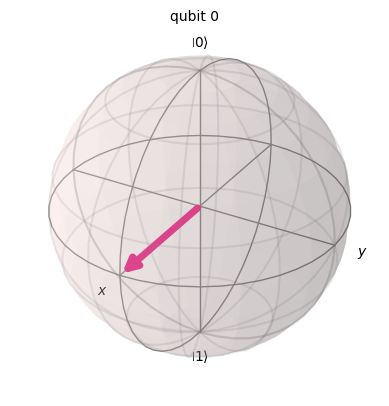

```python
qc = QuantumCircuit(1)

qc.h(0)

plot_bloch_multivector(get_state_vector(qc))
```

Now let's try to rotate it through an angle pi/4 around the Z-axis.

```python
qc.p((math.pi)/4,0)

qc.draw('mpl')
```

[output not shown]

Now let's look at the resulting statevector.

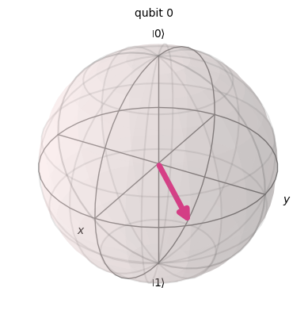

```python
plot_bloch_multivector(get_state_vector(qc))
```

Notice that, the statevector rotated in the counterclockwise direction. It will rotate clockwise if we mention the angle as negative.

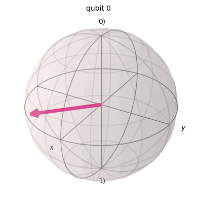

```python
qc = QuantumCircuit(1)

qc.h(0)
qc.p(-(math.pi)/4, 0)

plot_bloch_multivector(get_state_vector(qc))
```

# The Matrix

Since P-gate takes the rotation angle as an additional parameter, the matrix will obviously depend upon this angle. But let's check it for some specific angles.

```python
qc = QuantumCircuit(1)

qc.p((math.pi/6), 0)

print(get_unitary_matrix(qc))
```

```
Operator([[1.   +0.j , 0.   +0.j ],
          [0.   +0.j , 0.866+0.5j]],
         input_dims=(2,), output_dims=(2,))
```

```python
qc = QuantumCircuit(1)

qc.p((math.pi/4), 0)

print(get_unitary_matrix(qc))
```

```
Operator([[1.   +0.j   , 0.   +0.j   ],
          [0.   +0.j   , 0.707+0.707j]],
         input_dims=(2,), output_dims=(2,))
```

```python
qc = QuantumCircuit(1)

qc.p((math.pi/2), 0)

print(get_unitary_matrix(qc))
```

```
Operator([[1.+0.j, 0.+0.j],
          [0.+0.j, 0.+1.j]],
         input_dims=(2,), output_dims=(2,))
```

As expected, the first column never changes, implyting that the coefficient of |0> stays the same. But the coefficent of |1> gets rotated by the given angle.